# Predicting Profanity In YouTube Comments

## Analysis by Henry Chen and Aranya Banerjee

*Last updated on 12/15/2018*

### Introduction

The Trending page on YouTube is where YouTube showcases videos it thinks that all sorts of viewers would enjoy. So, the same set of Trending videos is shown to all YouTube users across the country. Typically, trending videos include new music videos from a popular artist or a new movie trailer from a popular franchise. However, there are also more "normal" videos that get their share of the spotlight.

While the videos in the Trending tab are meant for all audiences, there may be certain audiences (such as children and their parents) who would want to avoid videos or comment sections that may be more adult than others. Examining the question of how these audiences may filter this content from their media through the lens of data science provides a case study for the ability of machine learning in protecting consumers from undesired content.

In this project, we aim to use video properties such as title, publish date, genre, and so on to see if we can determine the polarity of a trending video. We will be focusing on Trending videos and their comments in the U.S.

#### Requirements

For the purposes of our project, we will be using a pre-prepared dataset of comments on trending youtube videos from Kaggle, found [here.](https://www.kaggle.com/datasnaek/youtube) The dataset contains trending videos from 2017.

In addition, we filter for profane words using a list available at [FrontGateMedia.](https://www.frontgatemedia.com/a-list-of-723-bad-words-to-blacklist-and-how-to-use-facebooks-moderation-tool/) *note: we've edited the file from FrontGateMedia to get rid of some unnecessary rows and data for easier parsing*

We will also be using the following libraries for analysis and visualization:

- [pandas](https://pandas.pydata.org/)
- [NumPy](https://www.numpy.org/)
- [scikit-learn](https://scikit-learn.org/stable/)
- [seaborn](https://seaborn.pydata.org/)
- [matplotlib](https://matplotlib.org/)

### Data Preparation

We import the following packages

```python
import pandas as pd
import numpy as np
import seaborn as sns
import matplotlib.pyplot as plt
from sklearn.model_selection import train_test_split # to split the data into two parts
from sklearn.ensemble import RandomForestRegressor # for random forest regressor
from sklearn.linear_model import LinearRegression
from sklearn import metrics
```

We now read in our dataset of comments on trending Youtube videos in the US. We sample a subset of the data that is representative but not so large that it presents performance issues.

```python
us_comments_all = pd.read_csv("UScomments.csv", error_bad_lines = False)
us_comments = us_comments_all.sample(n=50000)
columns = ['video_id', 'title', 'channel_title', 'category_id', 'tags', 'views', 'likes', 'dislikes', 'comment_total', 'thumbnail_link', 'date']
us_vids = pd.read_csv("USvideos.csv", usecols = columns)
```

```
b'Skipping line 41589: expected 4 fields, saw 11\nSkipping line 51628: expected 4 fields, saw 7\nSkipping line 114465: expected 4 fields, saw 5\n'
b'Skipping line 142496: expected 4 fields, saw 8\nSkipping line 189732: expected 4 fields, saw 6\nSkipping line 245218: expected 4 fields, saw 7\n'
b'Skipping line 388430: expected 4 fields, saw 5\n'
```

Notice that the comment text is a simple string. We will be able to take advantage of Python's built in libraries to search for matches of profane text within this datatype.

```python
us_comments.head()
```

|  | video_id | comment_text | likes | replies |
| --- | --- | --- | --- | --- |
| 639104 | 8I1B4n_8Cto | I LOVE this song! Kinda sounds like Beck has b... | 0 | 0 |
| 487550 | -B9z3az6Axc | The Beanz feature is ICONIC 🙌🏻 | 0 | 0 |
| 84828 | lv5uC6cfO5c | And there on gay looking mopeds lol | 0 | 0 |
| 159828 | UO0hIASuAqY | I m from Mexico city it's hard thank for prayers | 0 | 0 |
| 370638 | vaAzCXxAoQE | I absolutely love these Steelers post-game vid... | 0 | 0 |

A close examination of this data shows that there are multiple entries for each video for each day that it trended. We will address this problem of rows with duplicate video_id's in the next step. Also note that we have strings such as the title and channel title that we might extract some numerical information from. The tags string is given as a character separated string, which we may separate into a list of strings so that we can encode it into our model better. Data such as the thumbnail_link will not yield any information for profanity information. Finally, we have several numerical values that might bear some relationship to the prevalence of profanity in the video's comments. We will augment these values soon by extracting more information from the string values.

```python
us_vids.head()
```

|  | video_id | title | channel_title | category_id | tags | views | likes | dislikes | comment_total | thumbnail_link | date |
| --- | --- | --- | --- | --- | --- | --- | --- | --- | --- | --- | --- |
| 0 | XpVt6Z1Gjjo | 1 YEAR OF VLOGGING -- HOW LOGAN PAUL CHANGED Y... | Logan Paul Vlogs | 24 | logan paul vlog\|logan paul\|logan\|paul\|olympics... | 4394029 | 320053 | 5931 | 46245 | https://i.ytimg.com/vi/XpVt6Z1Gjjo/default.jpg | 13.09 |
| 1 | K4wEI5zhHB0 | iPhone X — Introducing iPhone X — Apple | Apple | 28 | Apple\|iPhone 10\|iPhone Ten\|iPhone\|Portrait Lig... | 7860119 | 185853 | 26679 | 0 | https://i.ytimg.com/vi/K4wEI5zhHB0/default.jpg | 13.09 |
| 2 | cLdxuaxaQwc | My Response | PewDiePie | 22 | [none] | 5845909 | 576597 | 39774 | 170708 | https://i.ytimg.com/vi/cLdxuaxaQwc/default.jpg | 13.09 |
| 3 | WYYvHb03Eog | Apple iPhone X first look | The Verge | 28 | apple iphone x hands on\|Apple iPhone X\|iPhone ... | 2642103 | 24975 | 4542 | 12829 | https://i.ytimg.com/vi/WYYvHb03Eog/default.jpg | 13.09 |
| 4 | sjlHnJvXdQs | iPhone X (parody) | jacksfilms | 23 | jacksfilms\|parody\|parodies\|iphone\|iphone x\|iph... | 1168130 | 96666 | 568 | 6666 | https://i.ytimg.com/vi/sjlHnJvXdQs/default.jpg | 13.09 |

Since the statistics for the trending videos is daily, we aggregate the information that is specific to each day by summing it and then merging it with any arbitrary row using only the data for that row that was not specific to the day.

```python
#aggregate daily data for each video
numeric_features = ["views","likes","dislikes","comment_total"]
remaining = ['video_id','title','channel_title','category_id','tags','thumbnail_link']
aggregate = us_vids.groupby(['video_id'], as_index=False)[numeric_features].sum()
uniques = us_vids.drop_duplicates(subset='video_id', keep='last')[remaining]
df = pd.merge(aggregate, uniques, on='video_id')
df.head()
```

|  | video_id | views | likes | dislikes | comment_total | title | channel_title | category_id | tags | thumbnail_link |
| --- | --- | --- | --- | --- | --- | --- | --- | --- | --- | --- |
| 0 | --JinobXWPk | 1319945 | 38949 | 533 | 6768 | DANGEROUS Jungle Spider! | Brave Wilderness | 15 | adventure\|adventurous\|animals\|breaking\|breakin... | https://i.ytimg.com/vi/--JinobXWPk/default.jpg |
| 1 | -1fzGnFwz9M | 189414 | 7070 | 112 | 288 | 9 Things You Need To Know About Kittens - Simo... | Simon's Cat | 15 | cartoon\|simons cat\|simon's cat\|simonscat\|simon... | https://i.ytimg.com/vi/-1fzGnFwz9M/default.jpg |
| 2 | -3AGlBYyLjo | 2143 | 16 | 2 | 4 | Best Tom Petty Interview Ever | CrazyLaughAction | 24 | tom\|petty\|tom petty\|Tom Petty\|Tom Petty (Music... | https://i.ytimg.com/vi/-3AGlBYyLjo/default.jpg |
| 3 | -3lMEZ6k5NA | 201901 | 10034 | 148 | 591 | 170912 BTS singing 'Closer' with The Chainsmokers | Kpop Plus01 | 10 | 170912 BTS | https://i.ytimg.com/vi/-3lMEZ6k5NA/default.jpg |
| 4 | -5sCWsLlTCI | 85052 | 1458 | 97 | 132 | SNL Host Kumail Nanjiani and P!nk Share Favori... | Saturday Night Live | 24 | saturday night live\|snl\|snl season 43\|kumail n... | https://i.ytimg.com/vi/-5sCWsLlTCI/default.jpg |

We read our profanity dictionary and examine how clean it is. We find that there are extraneous commas at the end of each entry. We remove these and now have a prepared dataframe for lookup of profane words.

```python
profanity = pd.read_csv('Terms-to-Block.csv')
us_comments['comment_text'] = us_comments['comment_text'].astype(str)
#removing commas
profanity['words'] = profanity['words'].str[0:-1]
profanity.head()
```

|  | words |
| --- | --- |
| 0 | a55 |
| 1 | a55hole |
| 2 | aeolus |
| 3 | ahole |
| 4 | anal |

We now use a list comprehension to check if each comment contains any words from our dictionary of profane words.

```python
#profanity indication
us_comments['profanity'] = [1 if True in [x in y for x in profanity['words']] else 0 for y in us_comments['comment_text']]
```

In order to enable our analysis of each video, we aggregate the data for each comment by averaging the presencence of profanity in each comment. This yields the percentage of comments on each video that had profanity in them.

```python
profane_sum = us_comments.groupby(['video_id'])[["profanity",]].mean()
#us_vids.merge(profane_sum, on = 'video_id', how = 'inner').drop_duplicates()#.dropna()
df = pd.merge(df, profane_sum, on='video_id')
df.head()
```

|  | video_id | views | likes | dislikes | comment_total | title | channel_title | category_id | tags | thumbnail_link | profanity |
| --- | --- | --- | --- | --- | --- | --- | --- | --- | --- | --- | --- |
| 0 | --JinobXWPk | 1319945 | 38949 | 533 | 6768 | DANGEROUS Jungle Spider! | Brave Wilderness | 15 | adventure\|adventurous\|animals\|breaking\|breakin... | https://i.ytimg.com/vi/--JinobXWPk/default.jpg | 0.250000 |
| 1 | -1fzGnFwz9M | 189414 | 7070 | 112 | 288 | 9 Things You Need To Know About Kittens - Simo... | Simon's Cat | 15 | cartoon\|simons cat\|simon's cat\|simonscat\|simon... | https://i.ytimg.com/vi/-1fzGnFwz9M/default.jpg | 0.000000 |
| 2 | -5sCWsLlTCI | 85052 | 1458 | 97 | 132 | SNL Host Kumail Nanjiani and P!nk Share Favori... | Saturday Night Live | 24 | saturday night live\|snl\|snl season 43\|kumail n... | https://i.ytimg.com/vi/-5sCWsLlTCI/default.jpg | 0.166667 |
| 3 | -6Zc8Co2H3w | 7139354 | 187351 | 4788 | 27070 | Honest Trailers - Star Trek: The Next Generation | Screen Junkies | 1 | screen junkies\|screenjunkies\|sj news\|honest tr... | https://i.ytimg.com/vi/-6Zc8Co2H3w/default.jpg | 0.208333 |
| 4 | -AJyaVduxCc | 974703 | 5107 | 178 | 675 | Why Is Ayesha Curry Sending Pics of Her Feet t... | The Real Daytime | 24 | the real\|daytime\|talk show\|women\|tamera mowry\|... | https://i.ytimg.com/vi/-AJyaVduxCc/default.jpg | 0.384615 |

```python
#tags as string lists
df['tags'] = df['tags'].map(lambda x: x.split('|'))
#number of tags
df['num_tags'] = df['tags'].apply(lambda x: len(x))
#percent of capital letters (out of letters) in the titles
df['percent_upper'] = df['title'].str.count(r'[A-Z]') / us_vids['title'].str.count(r'[a-z]|[A-Z]')
#title lengths
df['title_len'] = df['title'].str.len()
#like to dislike ratio
#avoiding division by zero
drop = df.drop(df[df['dislikes']==0].index)
df = drop
df['like_to_dislike'] = df['likes'] / df['dislikes']
df.head()
```

|  | video_id | views | likes | dislikes | comment_total | title | channel_title | category_id | tags | thumbnail_link | profanity | num_tags | percent_upper | title_len | like_to_dislike |
| --- | --- | --- | --- | --- | --- | --- | --- | --- | --- | --- | --- | --- | --- | --- | --- |
| 0 | --JinobXWPk | 1319945 | 38949 | 533 | 6768 | DANGEROUS Jungle Spider! | Brave Wilderness | 15 | [adventure, adventurous, animals, breaking, br... | https://i.ytimg.com/vi/--JinobXWPk/default.jpg | 0.250000 | 33 | 0.234043 | 24 | 73.075047 |
| 1 | -1fzGnFwz9M | 189414 | 7070 | 112 | 288 | 9 Things You Need To Know About Kittens - Simo... | Simon's Cat | 15 | [cartoon, simons cat, simon's cat, simonscat, ... | https://i.ytimg.com/vi/-1fzGnFwz9M/default.jpg | 0.000000 | 44 | 0.300000 | 59 | 63.125000 |
| 2 | -5sCWsLlTCI | 85052 | 1458 | 97 | 132 | SNL Host Kumail Nanjiani and P!nk Share Favori... | Saturday Night Live | 24 | [saturday night live, snl, snl season 43, kuma... | https://i.ytimg.com/vi/-5sCWsLlTCI/default.jpg | 0.166667 | 32 | 1.000000 | 55 | 15.030928 |
| 3 | -6Zc8Co2H3w | 7139354 | 187351 | 4788 | 27070 | Honest Trailers - Star Trek: The Next Generation | Screen Junkies | 1 | [screen junkies, screenjunkies, sj news, hones... | https://i.ytimg.com/vi/-6Zc8Co2H3w/default.jpg | 0.208333 | 15 | 0.333333 | 48 | 39.129282 |
| 4 | -AJyaVduxCc | 974703 | 5107 | 178 | 675 | Why Is Ayesha Curry Sending Pics of Her Feet t... | The Real Daytime | 24 | [the real, daytime, talk show, women, tamera m... | https://i.ytimg.com/vi/-AJyaVduxCc/default.jpg | 0.384615 | 8 | 0.769231 | 60 | 28.691011 |

```python
df.info()
```

```
<class 'pandas.core.frame.DataFrame'>
Int64Index: 2161 entries, 0 to 2177
Data columns (total 15 columns):
video_id           2161 non-null object
views              2161 non-null int64
likes              2161 non-null int64
dislikes           2161 non-null int64
comment_total      2161 non-null int64
title              2161 non-null object
channel_title      2161 non-null object
category_id        2161 non-null int64
tags               2161 non-null object
thumbnail_link     2161 non-null object
profanity          2161 non-null float64
num_tags           2161 non-null int64
percent_upper      2161 non-null float64
title_len          2161 non-null int64
like_to_dislike    2161 non-null float64
dtypes: float64(3), int64(7), object(5)
memory usage: 270.1+ KB
```

### Data Visualization and Exploration

We will now examine the relationships between our features, looking for correlations between variables and informing our decisions in what models we create

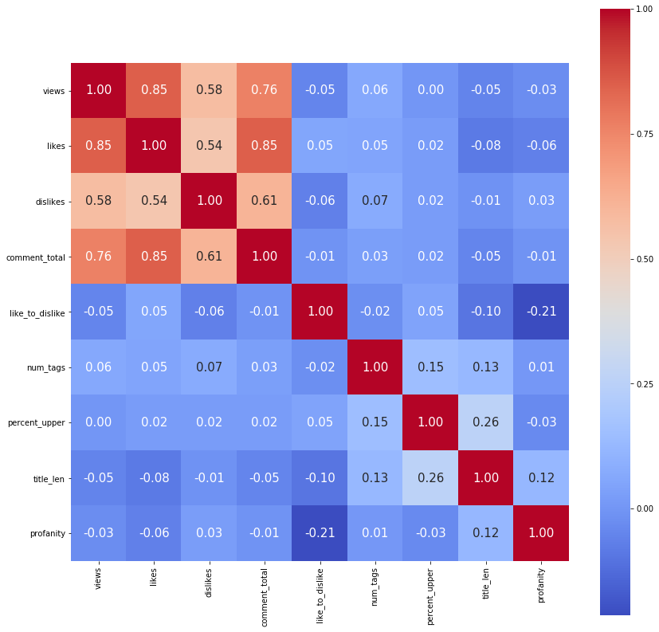

```python
# correlation map to examine the colinearity of columns
features = ["views","likes","dislikes","comment_total",'like_to_dislike','num_tags','percent_upper','title_len','profanity']
corr = df[features].corr() # .corr is used for find corelation
plt.figure(figsize=(14,14))
sns.heatmap(corr, cbar = True,  square = True, annot=True, fmt= '.2f',annot_kws={'size': 15},
           xticklabels= features, yticklabels= features,
           cmap= 'coolwarm') # for more on heatmap you can visit Link(http://seaborn.pydata.org/generated/seaborn.heatmap.html)
```

We examine the distribution of profanity presence in a video's comments. We find that with smaller sample sizes, the distribution is weighted heavily at 0 or 1 due to only one comment corresponding to a video, but as our sample size increases the distribution evens out.

[figure not shown]

```python
# show distribution of profanity in videos
sns.countplot(df['profanity'],label="Count")
```

```
array([[<matplotlib.axes._subplots.AxesSubplot object at 0x7f742969f550>]], dtype=object)
```

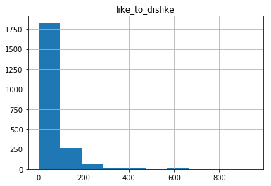

```python
df.hist(column="like_to_dislike")
```

```
array([[<matplotlib.axes._subplots.AxesSubplot object at 0x7f7428b948d0>]], dtype=object)
```

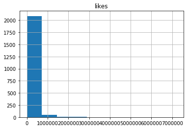

```python
df.hist(column="likes")
```

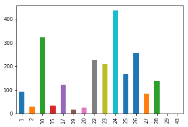

```python
df["category_id"].value_counts().sort_index().plot(kind='bar')
```

We find that there is mostly noise in the distribution of dilikes against the categories when stratified by how much profanity was present.

[figure not shown]

```python
sns.factorplot(x="category_id", y="dislikes", hue="profanity", data=df);
```

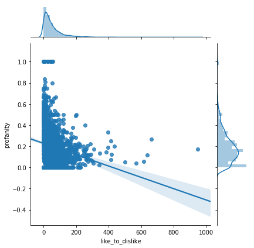

```python
sns.jointplot("like_to_dislike", "profanity", data=df, kind="reg")
```

### Data Modeling

We will now try to predict profanity levels based off of various regression and predictive models. We will be using the sklearn library for this.

```python
train, test = train_test_split(df, test_size = 0.3) # split main dataset into train and test
prediction_var = df.drop(columns=['profanity','video_id','title','channel_title','tags','thumbnail_link', 'percent_upper']).columns
train_X = train[prediction_var] # training data input
train_y = train.profanity # labeled classifications

test_X = test[prediction_var]
test_y = test.profanity # classification output
```

Now that we have our training and testing data, let's try some models. First, we will use a linear regressor.

```python
linr = LinearRegression()
linr.fit(train_X, train_y)

linr.score(test_X, test_y)
```

```
0.090642895560650638
```

Oof. Ouch. Owie. We see that our score is very small, meaning our model is extremely inaccurate/the errors are very large. Let's try a different approach.

```python
rf = RandomForestRegressor() # a simple random forest model
rf.fit(train_X,train_y) # train the model

rf.score(test_X, test_y)
```

```
0.035415865110192235
```

WOW this hurts. Once again, our score is very small.

If we had more time, we would most definitely find a way to add NLP to our project. This would allow us to analyze things such as titles and tags in a more useful way, such as considering genre, tone, and other sentiment-based analysis.

Closing note: after running several times, it seems the larger our sample, the greater our scores. Due to computational limitations, we capped out at around 50k comments. However, we believe that performance would have improved with more comments (ex: with only a few thousand comments, our scores were negative). That being said, it still would have been not-very-accurate, and we believe being able to use NLP/sentiment analysis on our string-based data would have helped our score significantly.